# Homework One

Melissa Franco

9/5/2020

```r
setwd("/Users/Melissa/Desktop/R/Algorithms/Homework/Homework 1")
#install.packages("e1071")
library(e1071)
#install.packages("fBasics")
library(fBasics)
```

## Exercise 1

### A)

Create a combined mpg variable called MPG_Combo which combines 55% of the MPG_City and 45% of the MPG_Highway.

Obtain a box plot for MPG_Combo and comment on what the plot tells us about fuel efficiencies.

```r
Cars <- read.csv("CARS.csv", header = TRUE)

MPG_Combo <- 0.55*Cars$MPG_City+0.45*Cars$MPG_Highway

Cars <- data.frame(Cars, MPG_Combo)
```

The box plot for MPG_Combo tells us that the overall overage for all vehicles’ combined MPG are more condensed and the distribution is slight positively skewed with various outliers exceeding 30 MPG.

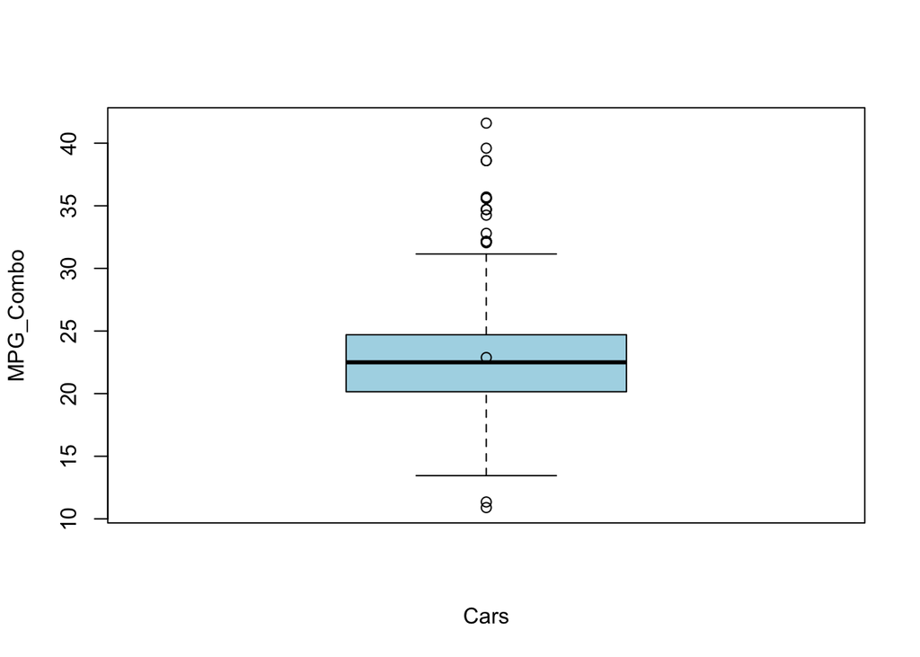

```r
boxplot(MPG_Combo, xlab = "Cars", ylab = "MPG_Combo", col = "lightblue"); points(mean(MPG_Combo), col="black")
```

### (B)

Obtain the box plots for MPG_Combo by Type and comment on any differences you notice between the different vehicle types combined fuel efficiency.

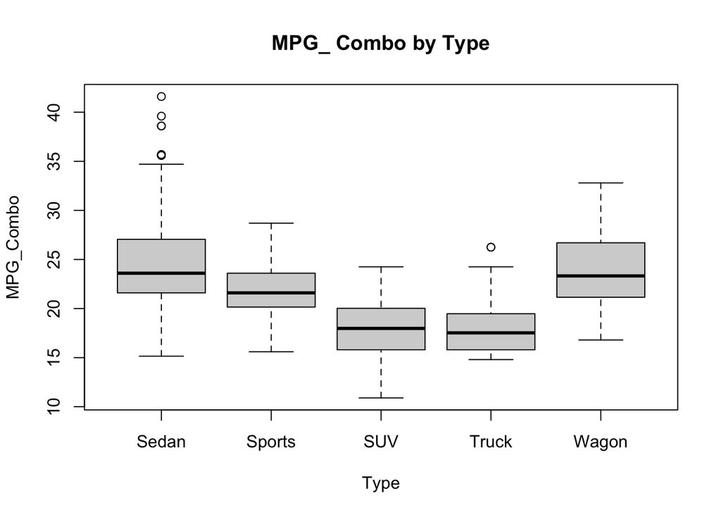

```r
boxplot(MPG_Combo ~ Type, data = Cars, main="MPG_ Combo by Type",
        xlab="Type", ylab="MPG_Combo", col = "lightgrey")
```

### C)

Obtain basic descriptive statistics for Invoice for all vehicles.

Comment on any general features and statistics of the data. Use visual and quantitative methods to comment on whether an assumption of normality would be reasonable for Invoice variable.

```r
summary(Cars$Invoice)
```

```
##    Min. 1st Qu.  Median    Mean 3rd Qu.    Max.
##    9875   18973   25672   30096   35777  173560
```

```r
var(Cars$Invoice)
```

```
## [1] 312488924
```

```r
skewness(Cars$Invoice, na.rm=TRUE)
```

```
## [1] 2.806001
## attr(,"method")
## [1] "moment"
```

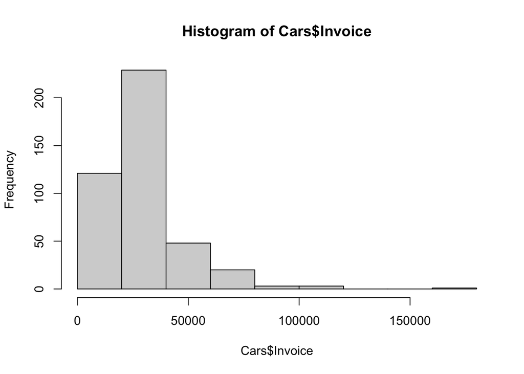

```r
hist(Cars$Invoice)
```

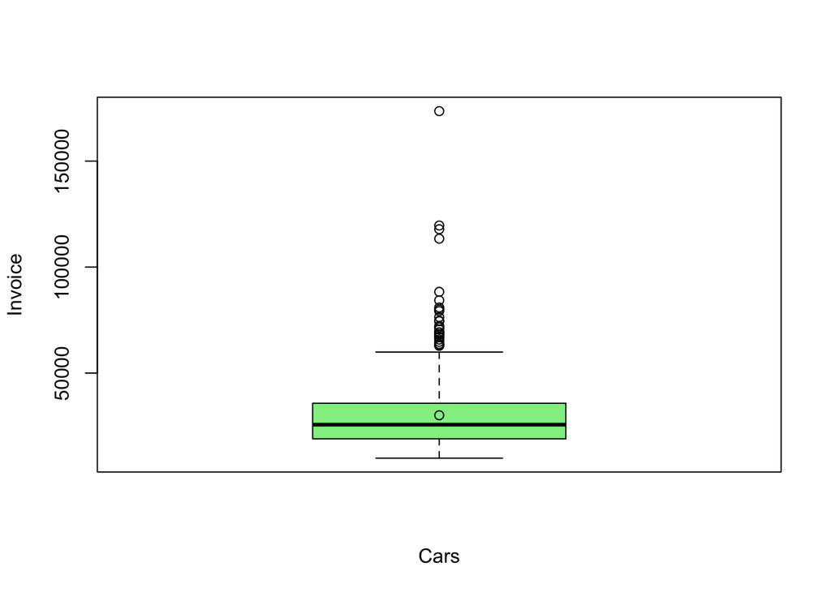

```r
boxplot(Cars$Invoice, xlab = "Cars", ylab = "Invoice", col = "lightgreen"); points(mean(Cars$Invoice), col="black")
```

```r
shapiro.test(Cars$Invoice)
```

```
##
##  Shapiro-Wilk normality test
##
## data:  Cars$Invoice
## W = 0.77353, p-value < 2.2e-16
```

The assumption of normality would not be reasonable for the Invoice variable.

Qualitatively by viewing the above histogram and box plot to see that they data is right skewed and does not represent any traits of normality. Also by observing the summary of the statistics the mean is greater than the median, therefore the distribution is positively (right) skewed.

Quantitatively we use the Shapiro-Wilk Test to check for normality. We are using a significance level of 0.05.

The Shapiro-Wilk test produces a p-value of 2.2e-16 which is less than our significance level thus we have enough information to reject the null hypothesis and accept the alternative. Our conclusion is that the data does not follow normal distribution.

### D)

Use visual and quantitative methods to comment on whether an assumption of normality would be reasonable for Invoice variable by Origin. (i.e., check normality of Invoice from i) Europe, ii) Asian, and iii)USA cars).

```r
summary(Cars$Invoice[Cars$Origin=="Asia"])
```

```
##    Min. 1st Qu.  Median    Mean 3rd Qu.    Max.
##    9875   16230   21428   22683   26813   79978
```

```r
summary(Cars$Invoice[Cars$Origin=="Europe"])
```

```
##    Min. 1st Qu.  Median    Mean 3rd Qu.    Max.
##   15437   31288   37575   44395   51042  173560
```

```r
summary(Cars$Invoice[Cars$Origin=="USA"])
```

```
##    Min. 1st Qu.  Median    Mean 3rd Qu.    Max.
##   10319   18927   23217   25949   30778   74451
```

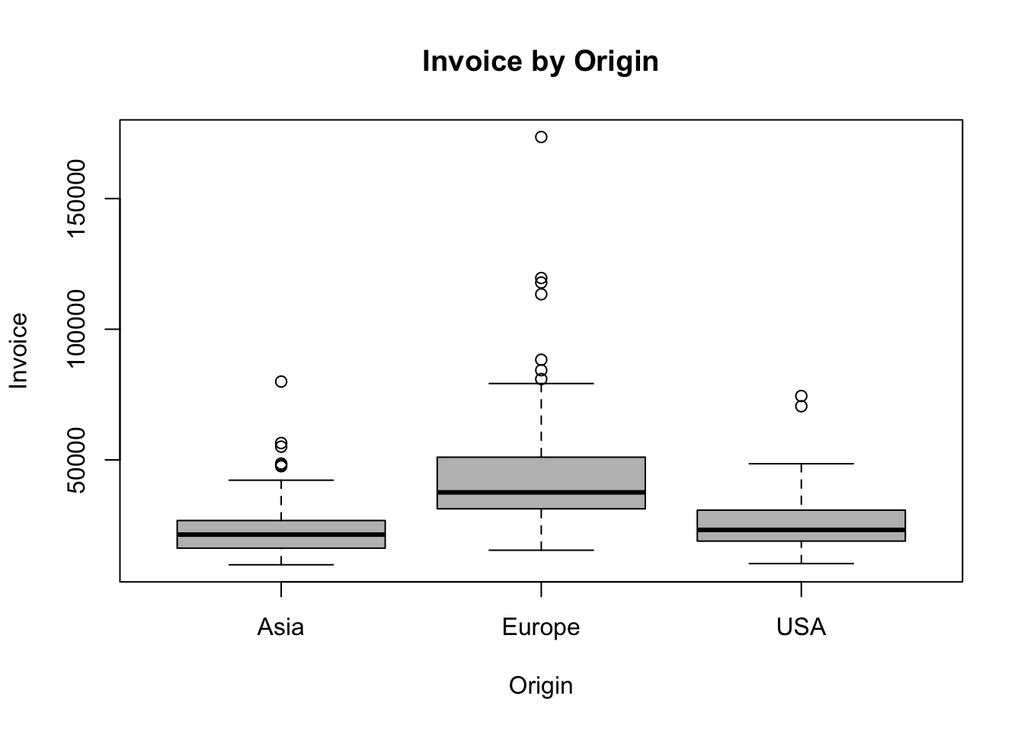

```r
boxplot(Invoice ~ Origin, data = Cars, main="Invoice by Origin",
        xlab="Origin", ylab="Invoice", col = "grey")
```

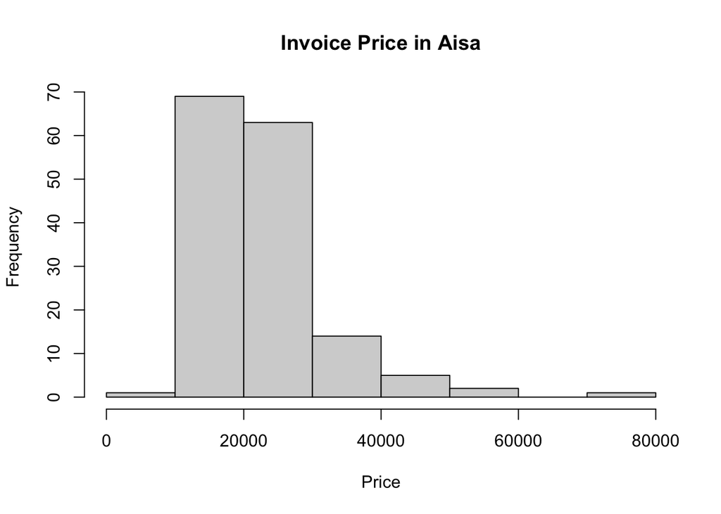

```r
hist(Cars$Invoice[Cars$Origin=="Asia"],main="Invoice Price in Aisa",
        xlab="Price", ylab="Frequency")
```

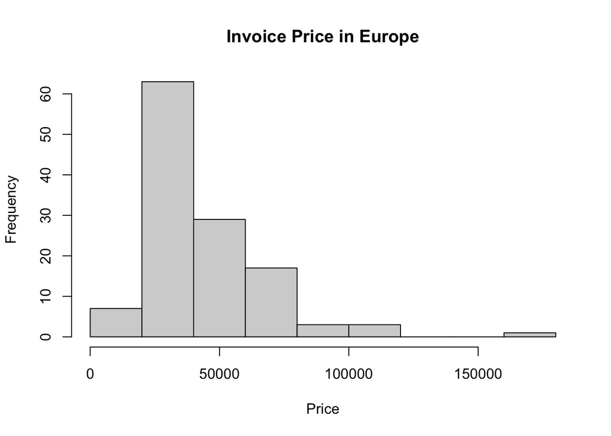

```r
hist(Cars$Invoice[Cars$Origin=="Europe"],main="Invoice Price in Europe",
        xlab="Price", ylab="Frequency")
```

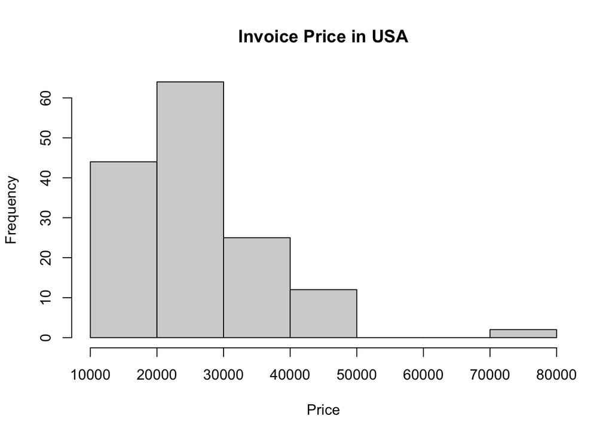

```r
hist(Cars$Invoice[Cars$Origin=="USA"],main="Invoice Price in USA",
        xlab="Price", ylab="Frequency")
```

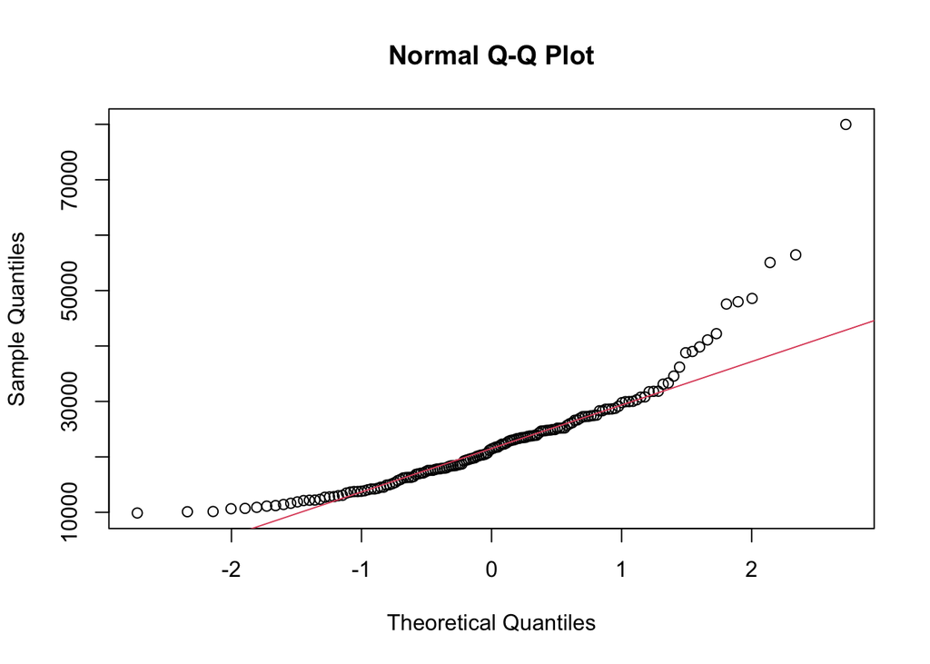

```r
qqnorm(Cars$Invoice[Cars$Origin=="Asia"]);qqline(Cars$Invoice[Cars$Origin=="Asia"], col = 2)
```

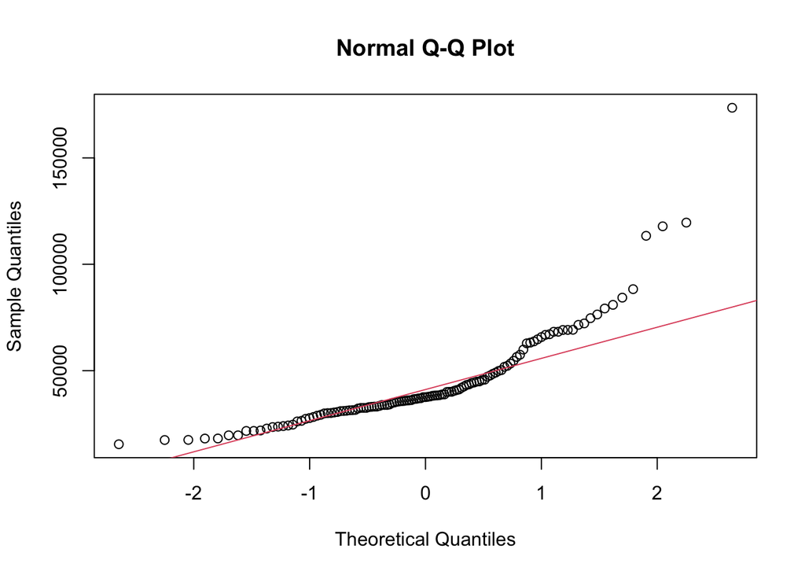

```r
qqnorm(Cars$Invoice[Cars$Origin=="Europe"]);qqline(Cars$Invoice[Cars$Origin=="Europe"], col = 2)
```

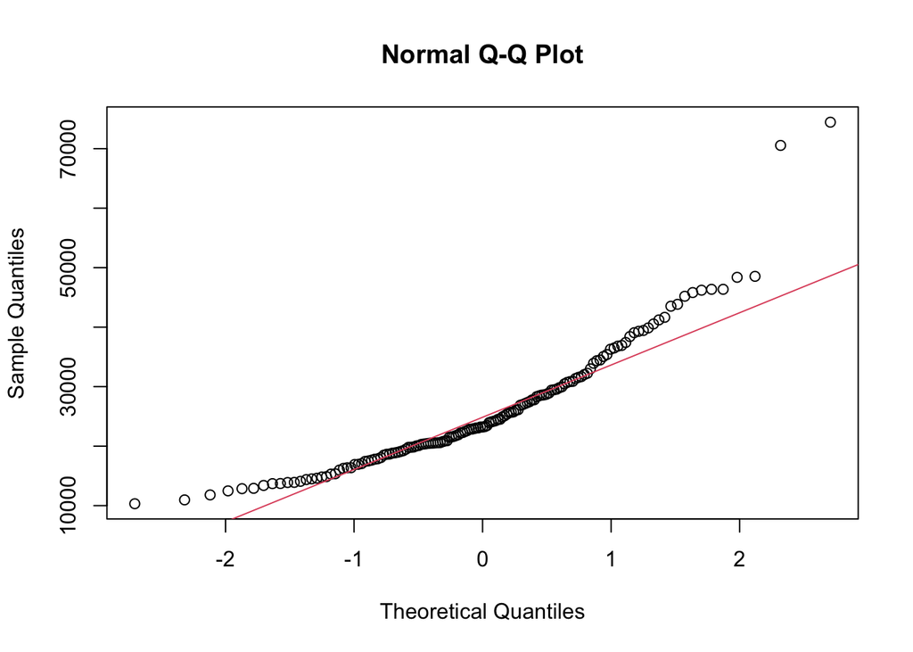

```r
qqnorm(Cars$Invoice[Cars$Origin=="USA"]);qqline(Cars$Invoice[Cars$Origin=="USA"], col = 2)
```

### Shapiro-Wilk Normality Test

If p-value is larger than significance level, we do not have enough evidence to reject the null hypothesis.

If p-value is smaller than significance level, we have enough evidence to reject the null hypothesis.

We will run the Shapiro-Wilk Normality test with a significance level of 0.05 for the following test hypothesis:

H0: Data follows normal distribution Ha: Data does not follow normal distribution

```r
shapiro.test(Cars$Invoice[Cars$Origin=="Asia"])
```

```
##
##  Shapiro-Wilk normality test
##
## data:  Cars$Invoice[Cars$Origin == "Asia"]
## W = 0.84696, p-value = 2.012e-11
```

```r
shapiro.test(Cars$Invoice[Cars$Origin=="Europe"])
```

```
##
##  Shapiro-Wilk normality test
##
## data:  Cars$Invoice[Cars$Origin == "Europe"]
## W = 0.79809, p-value = 1.024e-11
```

```r
shapiro.test(Cars$Invoice[Cars$Origin=="USA"])
```

```
##
##  Shapiro-Wilk normality test
##
## data:  Cars$Invoice[Cars$Origin == "USA"]
## W = 0.89222, p-value = 6.42e-09
```

We are using a significance level of 0.05.

All p-values are less than our significance level thus we have enough information to reject the null hypothesis, thus our conclusion is that the data does not follow normal distribution.

The assumption of normality would not be reasonable for the Invoice variable.

Qualitatively by viewing the above histogram, box plot, and QQ plot to see that they data is right skewed and does not represent any traits of normality. Also by observing the summary of the statistics the mean is greater than the median therefore the distribution is positively (right) skewed.

Quantitatively we use the Shapiro-Wilk Test to check for normality. All p-values are significantly less that our significance level of 0.05 so we will reject the null hypothesis and accept the alternative.

## Exercise 2

Perform a hypothesis test of whether cars originated in Europe have different invoice price than Asian cars, and state your conclusions

### A)

Which test should we perform, and why? Justify your answer based on findings on Exercise 1 (d).

As illustrated on Exercise 1(d) the data for Invoice by each Origin does not have a normal distribution so we will run the Wilcoxon rank-sum test.

First we need to determine if we will run a two-sided test or a one sided test:

Two-sided Test: Ho: two populations come from the same distribution Ha: one of the pops tends to have larger values (either population 1 or 2)

One-sided Test: Ha: pop 1 has larger values than pop 2

```r
Europe_Invoice <- c(Cars$Invoice[Cars$Origin=="Europe"])

Asia_Invoice  <- c(Cars$Invoice[Cars$Origin=="Asia"])

summary(Europe_Invoice)
```

```
##    Min. 1st Qu.  Median    Mean 3rd Qu.    Max.
##   15437   31288   37575   44395   51042  173560
```

```r
summary(Asia_Invoice)
```

```
##    Min. 1st Qu.  Median    Mean 3rd Qu.    Max.
##    9875   16230   21428   22683   26813   79978
```

From the above summary of the data it is evident that the population of Europe Invoices (population 1) tends to have larger values than Asia Invoices (population 2) so we will use a one sided test.

## B)

Specify null and alternative hypothesis

Ho: Invoice Price in Europe are equal to the Invoice Price in Asia

Ha: Invoice Price in Europe is larger than the Invoice Price in Asia

```r
wilcox.test(Europe_Invoice, Asia_Invoice)
```

```
##
##  Wilcoxon rank sum test with continuity correction
##
## data:  Europe_Invoice and Asia_Invoice
## W = 16721, p-value < 2.2e-16
## alternative hypothesis: true location shift is not equal to 0
```

## Exercise 3

Perform a hypothesis test -whether Wind in July has a different speed (mph) than Wind in August.

## A)

First we will determine if the distributions are normal.

```r
month7.wind = airquality[airquality$Month==7,"Wind"]
month8.wind = airquality[airquality$Month==8,"Wind"]

summary(month7.wind)
```

```
##    Min. 1st Qu.  Median    Mean 3rd Qu.    Max.
##   4.100   6.900   8.600   8.942  10.900  14.900
```

```r
summary(month8.wind)
```

```
##    Min. 1st Qu.  Median    Mean 3rd Qu.    Max.
##   2.300   6.600   8.600   8.794  11.200  15.500
```

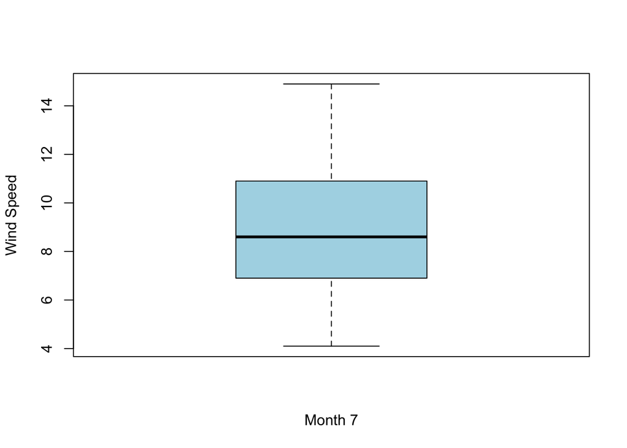

```r
boxplot(month7.wind,xlab = "Month 7", ylab = "Wind Speed", col = "lightblue"); points(mean(MPG_Combo), col="red")
```

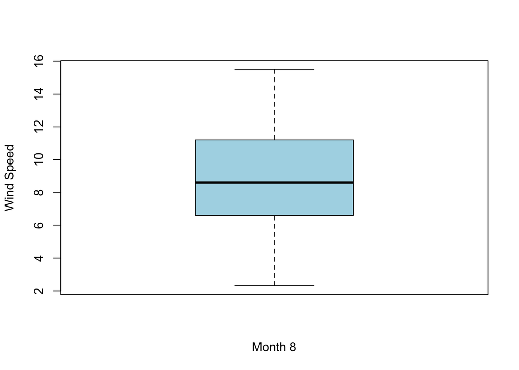

```r
boxplot(month8.wind, xlab = "Month 8", ylab = "Wind Speed", col = "lightblue"); points(mean(MPG_Combo), col="red")
```

```r
shapiro.test(month7.wind)
```

```
##
##  Shapiro-Wilk normality test
##
## data:  month7.wind
## W = 0.95003, p-value = 0.1564
```

```r
shapiro.test(month8.wind)
```

```
##
##  Shapiro-Wilk normality test
##
## data:  month8.wind
## W = 0.98533, p-value = 0.937
```

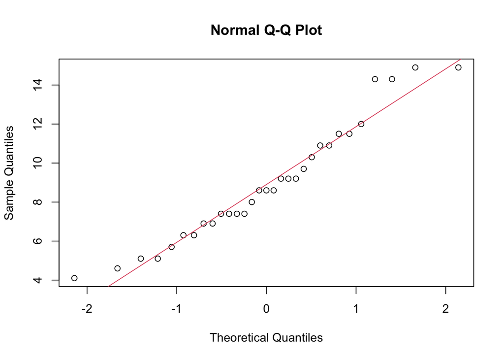

```r
qqnorm(month7.wind); qqline(month7.wind, col = 2)
```

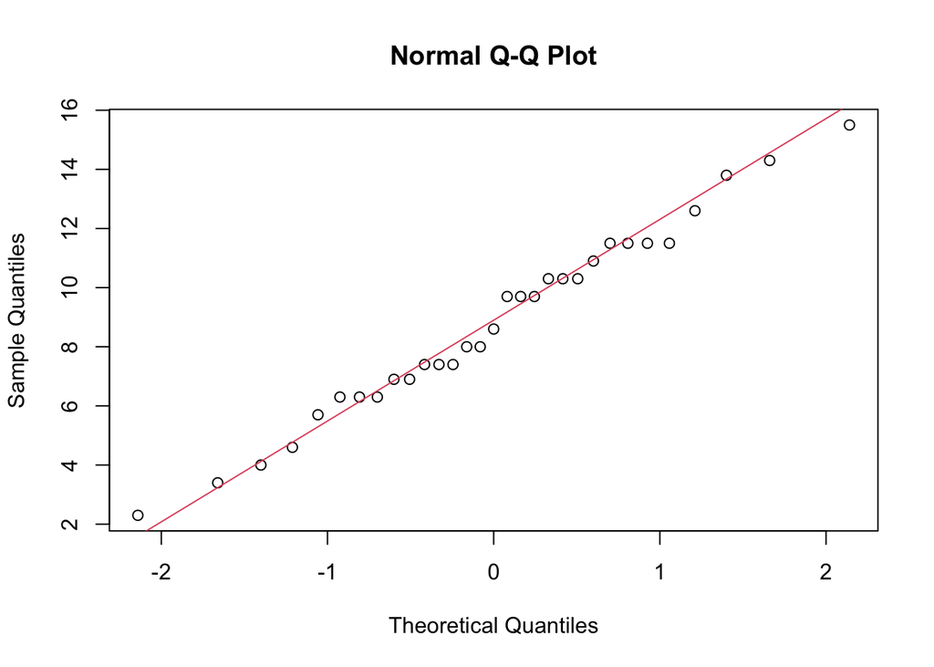

```r
qqnorm(month8.wind); qqline(month8.wind, col = 2)
```

We are using a significance level of 0.05.

By the Shapiro-Wilk test, our p-values are greater than our significance level thus we have enough information to accept the null hypothesis, thus our conclusion is that the data follows normal distribution.

Quantitatively we use the Shapiro-Wilk Test to check for normality. All p-values are significantly great that our significance level of 0.05 so we will accept the null hypothesis.

## B)

Specify null and alternative hypothesis.

Ho: Wind in July = Wind in August Ha: Wind in August != Wind in August

Data represents normal distribution so now we will check the variance.

```r
var(month7.wind)
```

```
## [1] 9.217183
```

```r
var(month8.wind)
```

```
## [1] 10.40662
```

```r
var.test(airquality$Month==7, airquality$Month==8, alternative = "two.sided")
```

```
##
##  F test to compare two variances
##
## data:  airquality$Month == 7 and airquality$Month == 8
## F = 1, num df = 152, denom df = 152, p-value = 1
## alternative hypothesis: true ratio of variances is not equal to 1
## 95 percent confidence interval:
##  0.7267711 1.3759491
## sample estimates:
## ratio of variances
##                  1
```

For the variance test we use the following null and alternative hypothesis:

Ho: Two groups have the same variance Ha: Two groups have different variances

```r
t.test(airquality$Month==7, airquality$Month==8, alterntive = "two.sided", var.equal = TRUE)
```

```
##
##  Two Sample t-test
##
## data:  airquality$Month == 7 and airquality$Month == 8
## t = 0, df = 304, p-value = 1
## alternative hypothesis: true difference in means is not equal to 0
## 95 percent confidence interval:
##  -0.09072836  0.09072836
## sample estimates:
## mean of x mean of y
## 0.2026144 0.2026144
```